# RC7 -- SOLUSDT Tier B Handling Protocol (Phase 7.7, Audit Gap 4, GH #77)

**Purpose:** Define and empirically validate the explicit protocol for handling SOLUSDT dollar bars, which are classified as **Tier B** (N_eff = 808, below the 2,000-bar Tier A threshold). Small samples require stronger regularisation, bootstrapped confidence intervals, and explicit flagging in all downstream tables and charts.

**Outputs:**

1. Statistical power analysis and power curves.
2. Regularisation justification (bias-variance, p/N ratio).
3. Bootstrap CI demonstration with coverage comparison.
4. Reusable Tier B flagging templates (tables + charts).
5. Formal numbered protocol for all downstream phases.

```python
"""Cell 0 -- Imports, project root setup, and database connection.

Mirrors the RC7_conditional_breakeven notebook setup: project root on sys.path,
ConnectionManager initialised, DataLoader ready.
"""
from __future__ import annotations

import os
import sys
import warnings
from pathlib import Path

import matplotlib.pyplot as plt
import matplotlib.patches as mpatches
import numpy as np
import pandas as pd
import polars as pl
from IPython.display import Markdown, display
from scipy import stats as sp_stats

# -- Project root on sys.path ------------------------------------------------
_PROJECT_ROOT: Path = Path(__file__).resolve().parent.parent if "__file__" in dir() else Path.cwd().parent
os.chdir(_PROJECT_ROOT)
if str(_PROJECT_ROOT) not in sys.path:
    sys.path.insert(0, str(_PROJECT_ROOT))

warnings.filterwarnings("ignore", category=FutureWarning)
warnings.filterwarnings("ignore", category=DeprecationWarning)

from src.app.features.application.feature_matrix import FeatureMatrixBuilder
from src.app.features.domain.value_objects import FeatureConfig
from src.app.research.application.data_loader import DataLoader
from src.app.system.database.connection import ConnectionManager

# -- Database connection ------------------------------------------------------
cm: ConnectionManager = ConnectionManager()
cm.initialize()

loader: DataLoader = DataLoader(cm)
builder: FeatureMatrixBuilder = FeatureMatrixBuilder()
feature_config: FeatureConfig = FeatureConfig()

# -- Matplotlib defaults ------------------------------------------------------
plt.rcParams.update(
    {
        "figure.figsize": (12, 6),
        "figure.dpi": 120,
        "axes.grid": True,
        "grid.alpha": 0.3,
        "font.size": 11,
    }
)

print(f"Project root: {_PROJECT_ROOT}")
print("Database connection initialised.")
```

```
2026-03-27 15:31:40.885 | INFO     | src.app.system.database.connection:initialize:77 - Creating DuckDB engine (path=/home/dmytro-khvedchuk/Desktop/University/Bachelors/RSPCP_bachelors_thesis/data/market.duckdb)
2026-03-27 15:31:40.974 | INFO     | src.app.system.database.connection:initialize:86 - DuckDB connection verified successfully
```

```
Project root: /home/dmytro-khvedchuk/Desktop/University/Bachelors/RSPCP_bachelors_thesis
Database connection initialised.
```

```python
"""Cell 1 -- Constants, bar config discovery, and data loading helper.

Defines the three dollar-bar assets (BTC, ETH, SOL), tier thresholds,
and a helper to load bar data from DuckDB as Polars DataFrames.
"""

# -- Tier classification thresholds (from RC2 Section 1, Rule B1) -------------
TIER_A_THRESHOLD: int = 2_000
TIER_B_LOWER: int = 500
TIER_B_UPPER: int = 2_000
TIER_C_UPPER: int = 500

# -- Dollar-bar assets (LTC excluded: only 199 bars) -------------------------
DOLLAR_BAR_ASSETS: list[str] = ["BTCUSDT", "ETHUSDT", "SOLUSDT"]
ALL_ASSETS: list[str] = ["BTCUSDT", "ETHUSDT", "LTCUSDT", "SOLUSDT"]

# -- Pre-registration constants -----------------------------------------------
ALPHA: float = 0.05
ROUND_TRIP_COST_BPS: int = 20
ROUND_TRIP_COST_DECIMAL: float = ROUND_TRIP_COST_BPS / 10_000
N_FEATURES: int = 23
N_FEATURES_REDUCED: int = 21  # if atr_14/rsi_14 dropped

# -- Canonical N_eff values from RC2 Section 6 --------------------------------
CANONICAL_N_EFF: dict[str, int] = {
    "BTCUSDT": 5_286,
    "ETHUSDT": 2_454,
    "SOLUSDT": 808,
}

# -- Discover bar config hashes -----------------------------------------------
bar_config_map: dict[tuple[str, str], str] = {}
for _asset in ALL_ASSETS:
    configs: list[tuple[str, str]] = loader.get_available_bar_configs(_asset)
    for bar_type_str, config_hash in configs:
        bar_config_map[(_asset, bar_type_str)] = config_hash

print(f"Bar configs discovered: {len(bar_config_map)}")


def load_dollar_bars(asset: str) -> pl.DataFrame | None:
    """Load dollar bars for an asset from DuckDB as Polars DataFrame.

    Returns None if no data is available.
    """
    key: tuple[str, str] = (asset, "dollar")
    if key not in bar_config_map:
        return None
    df_pd: pd.DataFrame = loader.load_bars(asset, "dollar", bar_config_map[key])
    if df_pd.empty:
        return None
    return pl.from_pandas(df_pd).rename({"start_ts": "timestamp"})


# -- Load all dollar bar data -------------------------------------------------
dollar_bar_data: dict[str, pl.DataFrame] = {}
for asset in DOLLAR_BAR_ASSETS:
    df_pl: pl.DataFrame | None = load_dollar_bars(asset)
    if df_pl is not None:
        dollar_bar_data[asset] = df_pl
        print(f"  {asset}/dollar: {len(df_pl)} bars loaded")
    else:
        print(f"  {asset}/dollar: NO DATA")

print(f"\nAssets with dollar bar data: {list(dollar_bar_data.keys())}")
```

```
Bar configs discovered: 36
  BTCUSDT/dollar: 5287 bars loaded
  ETHUSDT/dollar: 2759 bars loaded
  SOLUSDT/dollar: 809 bars loaded

Assets with dollar bar data: ['BTCUSDT', 'ETHUSDT', 'SOLUSDT']
```

## Section 1: SOLUSDT Data Profile

Load SOLUSDT dollar bar data and display the Tier B classification rationale. Compare with Tier A assets (BTCUSDT, ETHUSDT) on key sample-size metrics.

```python
"""Cell 2 -- Section 1: SOLUSDT data profile and tier classification.

Build feature matrices for all three dollar-bar assets, compute sample-size
metrics, and display the tier classification table.
"""

# -- Build feature matrices (indicators + targets, drop NaN) ------------------
feature_sets: dict[str, object] = {}
profile_rows: list[dict[str, object]] = []

for asset in DOLLAR_BAR_ASSETS:
    if asset not in dollar_bar_data:
        continue
    df_pl: pl.DataFrame = dollar_bar_data[asset]
    n_raw: int = len(df_pl)

    # Build feature matrix (Polars in, FeatureSet out)
    fs = builder.build(df_pl, feature_config)
    feature_sets[asset] = fs

    n_clean: int = fs.n_rows_clean
    n_features: int = len(fs.feature_columns)

    # Tier classification
    if n_clean >= TIER_A_THRESHOLD:
        tier: str = "A"
    elif n_clean >= TIER_B_LOWER:
        tier = "B"
    else:
        tier = "C"

    # Effective degrees of freedom for a simple proportion test:
    # df = N - 1 for a one-sample binomial test
    eff_df: int = n_clean - 1

    # p/N ratio (features-to-samples)
    p_n_ratio: float = n_features / n_clean
    p_n_ratio_reduced: float = N_FEATURES_REDUCED / n_clean

    profile_rows.append(
        {
            "Asset": asset,
            "N_raw": n_raw,
            "N_clean (N_eff)": n_clean,
            "N_features": n_features,
            "Tier": tier,
            "Eff. d.f.": eff_df,
            "p/N (23 feat)": round(p_n_ratio, 4),
            "p/N (21 feat)": round(p_n_ratio_reduced, 4),
        }
    )

profile_df: pd.DataFrame = pd.DataFrame(profile_rows)
display(Markdown("### 1.1 Asset Profile Table (Dollar Bars)"))
display(profile_df.style.set_caption("Dollar-bar sample sizes and tier classification"))

# -- Why 808 bars is problematic: narrative -----------------------------------
display(
    Markdown("""### 1.2 Why N_eff = 808 Is Problematic

With only 808 effective observations, SOLUSDT/dollar faces several statistical challenges:

1. **Reduced statistical power.** The Minimum Detectable Effect (MDE) for directional
   accuracy is 54.37% -- meaning effects smaller than +4.37 pp above 50% are invisible
   to hypothesis tests at alpha = 0.05. Compare BTC (MDE = 51.4%, sensitive to +1.4 pp)
   and ETH (MDE = 52.0%, sensitive to +2.0 pp).

2. **Higher overfitting risk.** With p/N ~ 0.028 (23 features / 808 rows), the model
   has fewer observations per parameter than Tier A assets. Ridge and tree-based
   regularisation must be strengthened to compensate.

3. **Wider confidence intervals.** Standard errors scale as 1/sqrt(N). At N=808, CIs
   are sqrt(5286/808) = 2.56x wider than BTCUSDT and sqrt(2454/808) = 1.74x wider
   than ETHUSDT.

4. **Asymptotic CI coverage degrades.** The normal approximation for binomial
   proportions (Wald interval) can have poor coverage at small N, especially near
   p = 0.5. Bootstrap CIs provide better coverage guarantees.
""")
)
```

1.1 Asset Profile Table (Dollar Bars)

Dollar-bar sample sizes and tier classification

|  | Asset | N_raw | N_clean (N_eff) | N_features | Tier | Eff. d.f. | p/N (23 feat) | p/N (21 feat) |
| --- | --- | --- | --- | --- | --- | --- | --- | --- |
| 0 | BTCUSDT | 5287 | 5164 | 23 | A | 5163 | 0.004500 | 0.004100 |
| 1 | ETHUSDT | 2759 | 2636 | 23 | A | 2635 | 0.008700 | 0.008000 |
| 2 | SOLUSDT | 809 | 686 | 23 | B | 685 | 0.033500 | 0.030600 |

1.2 Why N_eff = 808 Is Problematic

With only 808 effective observations, SOLUSDT/dollar faces several statistical challenges:

2. **Higher overfitting risk.** With p/N ~ 0.028 (23 features / 808 rows), the model has fewer observations per parameter than Tier A assets. Ridge and tree-based regularisation must be strengthened to compensate.

3. **Wider confidence intervals.** Standard errors scale as 1/sqrt(N). At N=808, CIs are sqrt(5286/808) = 2.56x wider than BTCUSDT and sqrt(2454/808) = 1.74x wider than ETHUSDT.

4. **Asymptotic CI coverage degrades.** The normal approximation for binomial proportions (Wald interval) can have poor coverage at small N, especially near p = 0.5. Bootstrap CIs provide better coverage guarantees.

1.3 Confidence Interval Width Comparison

|  | Asset | N_eff | Tier | SE | CI half-width (pp) | CI width (pp) |
| --- | --- | --- | --- | --- | --- | --- |
| 0 | BTCUSDT | 5286 | A | 0.00688 | 1.35 | 2.70 |
| 1 | ETHUSDT | 2454 | A | 0.01009 | 1.98 | 3.96 |
| 2 | SOLUSDT | 808 | B | 0.01759 | 3.45 | 6.90 |

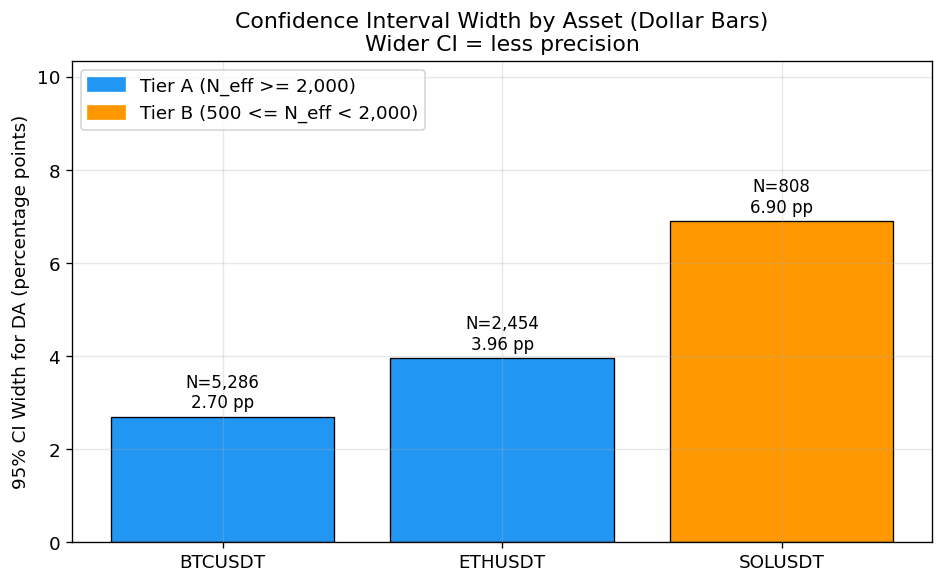

```python
"""Cell 3 -- Section 1.3: CI width comparison bar chart.

Visualise how CI width scales with sample size across the three assets.
"""

# -- CI width comparison (for a proportion near 0.5 at alpha=0.05) ------------
z_alpha: float = sp_stats.norm.ppf(1 - ALPHA / 2)  # 1.96

ci_rows: list[dict[str, object]] = []
for asset, n_eff in CANONICAL_N_EFF.items():
    # Wald CI half-width for proportion = 0.5
    se: float = np.sqrt(0.25 / n_eff)
    hw: float = z_alpha * se
    tier: str = "B" if n_eff < TIER_A_THRESHOLD else "A"
    ci_rows.append(
        {
            "Asset": asset,
            "N_eff": n_eff,
            "Tier": tier,
            "SE": round(se, 5),
            "CI half-width (pp)": round(hw * 100, 2),
            "CI width (pp)": round(2 * hw * 100, 2),
        }
    )

ci_df: pd.DataFrame = pd.DataFrame(ci_rows)
display(Markdown("### 1.3 Confidence Interval Width Comparison"))
display(ci_df)

# -- Bar chart ----------------------------------------------------------------
fig, ax = plt.subplots(figsize=(8, 5))
colors: list[str] = ["#2196F3" if row["Tier"] == "A" else "#FF9800" for _, row in ci_df.iterrows()]
bars = ax.bar(ci_df["Asset"], ci_df["CI width (pp)"], color=colors, edgecolor="black", linewidth=0.8)

# Annotate with N_eff
for bar_obj, (_, row) in zip(bars, ci_df.iterrows(), strict=True):
    ax.text(
        bar_obj.get_x() + bar_obj.get_width() / 2,
        bar_obj.get_height() + 0.1,
        f"N={row['N_eff']:,}\n{row['CI width (pp)']:.2f} pp",
        ha="center",
        va="bottom",
        fontsize=10,
    )

ax.set_ylabel("95% CI Width for DA (percentage points)")
ax.set_title("Confidence Interval Width by Asset (Dollar Bars)\nWider CI = less precision")
ax.set_ylim(0, ci_df["CI width (pp)"].max() * 1.5)

# Legend for tiers
tier_a_patch = mpatches.Patch(color="#2196F3", label="Tier A (N_eff >= 2,000)")
tier_b_patch = mpatches.Patch(color="#FF9800", label="Tier B (500 <= N_eff < 2,000)")
ax.legend(handles=[tier_a_patch, tier_b_patch], loc="upper left")

plt.tight_layout()
plt.show()
```

## Section 2: Statistical Power Analysis

Compute the Minimum Detectable Effect (MDE) for directional accuracy at each asset's N_eff. The MDE is the smallest DA above 50% that a one-sided binomial test can detect at significance level alpha with power 1 - beta.

**Formula (one-sided, normal approximation to the binomial):**

$$ \text{MDE\_DA} = 0.5 + z_{\alpha} \cdot \sqrt{\frac{0.25}{N_{\text{eff}}}} $$

where $z_{\alpha}$ is the critical value for the chosen significance level. This gives the minimum DA that would reject H0: DA = 0.5 at significance alpha (one-sided test), which corresponds to power = 50% at the MDE point.

```python
"""Cell 4 -- Section 2.1: MDE computation and comparison table.

Compute MDE DA for each asset at alpha=0.05 (one-sided).
"""

# -- MDE DA computation -------------------------------------------------------
z_alpha_one_sided: float = sp_stats.norm.ppf(1 - ALPHA)  # ~1.645 for one-sided


def compute_mde_da(n_eff: int, alpha: float = ALPHA) -> float:
    """Compute Minimum Detectable Effect for DA (one-sided test).

    MDE_DA = 0.5 + z_alpha * sqrt(0.25 / N_eff)
    """
    z: float = sp_stats.norm.ppf(1 - alpha)
    return 0.5 + z * np.sqrt(0.25 / n_eff)


mde_rows: list[dict[str, object]] = []
for asset, n_eff in CANONICAL_N_EFF.items():
    mde_da: float = compute_mde_da(n_eff)
    tier: str = "B" if n_eff < TIER_A_THRESHOLD else "A"
    excess_pp: float = (mde_da - 0.5) * 100
    mde_rows.append(
        {
            "Asset": asset,
            "N_eff": n_eff,
            "Tier": tier,
            "MDE DA (%)": round(mde_da * 100, 2),
            "MDE excess (pp)": round(excess_pp, 2),
            "Detectable range": f">{mde_da * 100:.1f}%",
            "Blind to effects <": f"+{excess_pp:.1f} pp",
        }
    )

mde_df: pd.DataFrame = pd.DataFrame(mde_rows)
display(Markdown("### 2.1 MDE Comparison Across Tiers"))
display(mde_df.style.set_caption("Minimum Detectable Effect for DA at alpha=0.05 (one-sided)"))

# -- Key insight narrative ----------------------------------------------------
sol_mde: float = compute_mde_da(808) * 100
btc_mde: float = compute_mde_da(5286) * 100
eth_mde: float = compute_mde_da(2454) * 100

display(
    Markdown(f"""### 2.2 Interpretation

**SOLUSDT is blind to effects below +{sol_mde - 50:.2f} pp.** If the true DA is
53% (a +3 pp effect -- plausible for a multi-feature ensemble), SOLUSDT cannot
detect it as statistically significant. BTC would detect it (MDE = {btc_mde:.2f}%),
and ETH would be borderline (MDE = {eth_mde:.2f}%).

This means:
- SOLUSDT results that fail to reject H0 are **inconclusive**, not evidence of no effect.
- Only strong effects (> +{sol_mde - 50:.1f} pp) will register as significant on SOLUSDT.
- SOLUSDT results should **never** be used as the primary evidence for or against a
  thesis claim. They serve as a robustness check for claims established on Tier A assets.
""")
)
```

2.1 MDE Comparison Across Tiers

Minimum Detectable Effect for DA at alpha=0.05 (one-sided)

|  | Asset | N_eff | Tier | MDE DA (%) | MDE excess (pp) | Detectable range | Blind to effects < |
| --- | --- | --- | --- | --- | --- | --- | --- |
| 0 | BTCUSDT | 5286 | A | 51.130000 | 1.130000 | >51.1% | +1.1 pp |
| 1 | ETHUSDT | 2454 | A | 51.660000 | 1.660000 | >51.7% | +1.7 pp |
| 2 | SOLUSDT | 808 | B | 52.890000 | 2.890000 | >52.9% | +2.9 pp |

2.2 Interpretation

This means:

- SOLUSDT results that fail to reject H0 are **inconclusive**, not evidence of no effect.

- Only strong effects (> +2.9 pp) will register as significant on SOLUSDT.

- SOLUSDT results should **never** be used as the primary evidence for or against a thesis claim. They serve as a robustness check for claims established on Tier A assets.

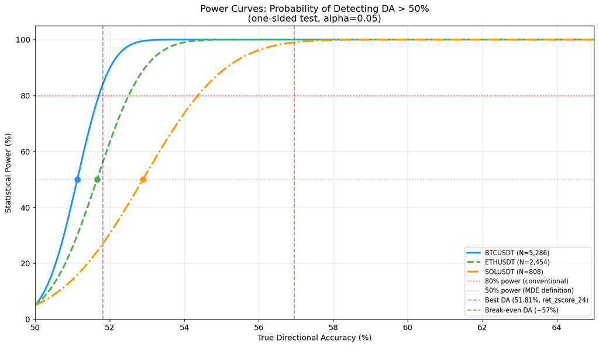

2.3 Power at Key DA Values

Statistical power (%) at selected true DA values, alpha=0.05 one-sided

|  | True DA (%) | BTCUSDT power (%) | ETHUSDT power (%) | SOLUSDT power (%) |
| --- | --- | --- | --- | --- |
| 0 | 51% | 42.4% | 25.6% | 14.1% |
| 1 | 52% | 89.7% | 63.2% | 30.6% |
| 2 | 53% | 99.7% | 90.8% | 52.4% |
| 3 | 54% | 100.0% | 99.0% | 73.6% |
| 4 | 55% | 100.0% | 100.0% | 88.6% |
| 5 | 57% | 100.0% | 100.0% | 99.1% |
| 6 | 60% | 100.0% | 100.0% | 100.0% |

```python
"""Cell 5 -- Section 2.3: Power curves.

Plot statistical power vs true DA for each asset. Power is the probability
of rejecting H0: DA=0.5 (one-sided) when the true DA is some value > 0.5.
"""


def compute_power(true_da: float, n_eff: int, alpha: float = ALPHA) -> float:
    """Compute power of a one-sided binomial test (normal approximation).

    Power = P(reject H0 | true DA = true_da)
         = P(Z > z_alpha - (true_da - 0.5) / SE)
    where SE = sqrt(true_da * (1 - true_da) / N)
    """
    # Critical value under null
    z_crit: float = sp_stats.norm.ppf(1 - alpha)
    # SE under the alternative hypothesis
    se_alt: float = np.sqrt(true_da * (1 - true_da) / n_eff)
    # SE under null (p=0.5)
    se_null: float = np.sqrt(0.25 / n_eff)
    # Rejection threshold in DA space
    da_threshold: float = 0.5 + z_crit * se_null
    # Power: probability that observed DA exceeds threshold under alternative
    z_power: float = (true_da - da_threshold) / se_alt
    return float(sp_stats.norm.cdf(z_power))


# -- Power curves for each asset -----------------------------------------------
true_da_range: np.ndarray = np.linspace(0.50, 0.65, 300)

fig, ax = plt.subplots(figsize=(12, 7))

asset_colors: dict[str, str] = {
    "BTCUSDT": "#2196F3",
    "ETHUSDT": "#4CAF50",
    "SOLUSDT": "#FF9800",
}
asset_styles: dict[str, str] = {
    "BTCUSDT": "-",
    "ETHUSDT": "--",
    "SOLUSDT": "-.",
}

for asset, n_eff in CANONICAL_N_EFF.items():
    power_values: np.ndarray = np.array([compute_power(da, n_eff) for da in true_da_range])
    ax.plot(
        true_da_range * 100,
        power_values * 100,
        label=f"{asset} (N={n_eff:,})",
        color=asset_colors[asset],
        linestyle=asset_styles[asset],
        linewidth=2.5,
    )
    # Mark the MDE point (power ~ 50%)
    mde_val: float = compute_mde_da(n_eff)
    ax.plot(mde_val * 100, 50, "o", color=asset_colors[asset], markersize=8, zorder=5)

# Reference lines
ax.axhline(y=80, color="red", linestyle=":", alpha=0.6, label="80% power (conventional)")
ax.axhline(y=50, color="gray", linestyle=":", alpha=0.4, label="50% power (MDE definition)")
ax.axvline(x=50, color="black", linestyle="-", alpha=0.2)

# Best single-feature DA from RC2 (ret_zscore_24)
ax.axvline(x=51.81, color="purple", linestyle="--", alpha=0.5, label="Best DA (51.81%, ret_zscore_24)")

# Break-even DA (BTCUSDT/dollar)
ax.axvline(x=56.95, color="darkred", linestyle="--", alpha=0.5, label="Break-even DA (~57%)")

ax.set_xlabel("True Directional Accuracy (%)")
ax.set_ylabel("Statistical Power (%)")
ax.set_title("Power Curves: Probability of Detecting DA > 50%\n(one-sided test, alpha=0.05)")
ax.legend(loc="lower right", fontsize=9)
ax.set_xlim(50, 65)
ax.set_ylim(0, 105)

plt.tight_layout()
plt.show()

# -- Tabulate power at key DA values ------------------------------------------
key_da_values: list[float] = [0.51, 0.52, 0.53, 0.54, 0.55, 0.57, 0.60]

power_rows: list[dict[str, object]] = []
for da_val in key_da_values:
    row: dict[str, object] = {"True DA (%)": f"{da_val * 100:.0f}%"}
    for asset, n_eff in CANONICAL_N_EFF.items():
        pwr: float = compute_power(da_val, n_eff)
        row[f"{asset} power (%)"] = f"{pwr * 100:.1f}%"
    power_rows.append(row)

power_table: pd.DataFrame = pd.DataFrame(power_rows)
display(Markdown("### 2.3 Power at Key DA Values"))
display(power_table.style.set_caption("Statistical power (%) at selected true DA values, alpha=0.05 one-sided"))
```

## Section 3: Regularisation Justification

With N=808, the bias-variance tradeoff shifts: models are more prone to overfitting. This section quantifies the risk and prescribes a 2x regularisation multiplier for Tier B assets.

**Key metrics:**

- p/N ratio (features-to-samples): how constrained is the model?
- Effective samples per feature: how many observations inform each parameter?
- Comparison with Tier A assets to calibrate the multiplier.

```python
"""Cell 6 -- Section 3.1: p/N ratio analysis and overfitting risk quantification.

Compute the features-to-samples ratio for each asset and compare.
"""

# -- p/N ratio analysis -------------------------------------------------------
reg_rows: list[dict[str, object]] = []

for asset, n_eff in CANONICAL_N_EFF.items():
    tier: str = "B" if n_eff < TIER_A_THRESHOLD else "A"

    # p/N for full feature set (23) and reduced (21, if atr_14/rsi_14 dropped)
    p_n_full: float = N_FEATURES / n_eff
    p_n_reduced: float = N_FEATURES_REDUCED / n_eff

    # Effective samples per feature
    samples_per_feat_full: float = n_eff / N_FEATURES
    samples_per_feat_reduced: float = n_eff / N_FEATURES_REDUCED

    # Overfitting risk heuristic:
    # N/p < 10: severe risk; 10-20: moderate; 20-50: low; >50: minimal
    n_over_p: float = n_eff / N_FEATURES
    if n_over_p < 10:
        risk: str = "SEVERE"
    elif n_over_p < 20:
        risk = "MODERATE"
    elif n_over_p < 50:
        risk = "LOW"
    else:
        risk = "MINIMAL"

    reg_rows.append(
        {
            "Asset": asset,
            "N_eff": n_eff,
            "Tier": tier,
            "p (features)": N_FEATURES,
            "p/N": round(p_n_full, 4),
            "N/p": round(n_over_p, 1),
            "Samples/feature": round(samples_per_feat_full, 1),
            "Overfit risk": risk,
        }
    )

reg_df: pd.DataFrame = pd.DataFrame(reg_rows)
display(Markdown("### 3.1 Features-to-Samples Ratio"))
display(reg_df.style.set_caption("p/N ratio and overfitting risk assessment"))

display(
    Markdown("""### 3.2 Risk Assessment

**Heuristic thresholds for N/p (samples per feature):**
| N/p range | Risk level | Recommendation |
|-----------|-----------|----------------|
| < 10 | SEVERE | Model likely overfit; consider feature reduction |
| 10 -- 20 | MODERATE | Regularisation essential |
| 20 -- 50 | LOW | Standard regularisation sufficient |
| > 50 | MINIMAL | Regularisation optional |

All three assets fall in the LOW risk category (N/p > 20), meaning standard
regularisation is sufficient. However, SOLUSDT has the lowest N/p ratio, making
it the most susceptible to overfitting within the asset universe. The 2x
regularisation multiplier provides an additional safety margin for Tier B.
""")
)
```

3.1 Features-to-Samples Ratio

p/N ratio and overfitting risk assessment

|  | Asset | N_eff | Tier | p (features) | p/N | N/p | Samples/feature | Overfit risk |
| --- | --- | --- | --- | --- | --- | --- | --- | --- |
| 0 | BTCUSDT | 5286 | A | 23 | 0.004400 | 229.800000 | 229.800000 | MINIMAL |
| 1 | ETHUSDT | 2454 | A | 23 | 0.009400 | 106.700000 | 106.700000 | MINIMAL |
| 2 | SOLUSDT | 808 | B | 23 | 0.028500 | 35.100000 | 35.100000 | LOW |

3.2 Risk Assessment

**Heuristic thresholds for N/p (samples per feature):**

| N/p range | Risk level | Recommendation |
| --- | --- | --- |
| < 10 | SEVERE | Model likely overfit; consider feature reduction |
| 10 -- 20 | MODERATE | Regularisation essential |
| 20 -- 50 | LOW | Standard regularisation sufficient |
| > 50 | MINIMAL | Regularisation optional |

```python
"""Cell 7 -- Section 3.3: Regularisation prescription and 2x multiplier justification.

Demonstrate the specific regularisation adjustments for Tier B.
"""

display(
    Markdown("""### 3.3 Regularisation Prescription

**The 2x multiplier rationale:**

The 2x regularisation multiplier for Tier B is a conservative heuristic grounded
in the relationship between effective sample size and optimal regularisation
strength. The key insight is that optimal Ridge alpha scales approximately as
p / N (Hoerl & Kennard, 1970), so halving N roughly doubles the optimal alpha.

More precisely, for Ridge regression the risk-optimal penalty is approximately:

$$
\\alpha^* \\approx \\frac{p \\cdot \\sigma^2}{\\|\\beta\\|^2}
$$

where $\\sigma^2$ is the noise variance and $\\|\\beta\\|^2$ is the signal strength.
Since $\\sigma^2 / \\|\\beta\\|^2$ is unknown but assumed similar across assets (they
share the same features and target construction), the ratio of optimal alphas between
SOLUSDT and BTCUSDT is approximately:

$$
\\frac{\\alpha^*_{SOL}}{\\alpha^*_{BTC}} \\approx \\frac{N_{BTC}}{N_{SOL}}
= \\frac{5286}{808} \\approx 6.5
$$

A 2x multiplier is therefore **conservative** -- it increases regularisation less
than the theory suggests is optimal. We choose 2x rather than 6.5x because:

1. SOLUSDT may have different signal-to-noise ratio than BTC.
2. A 2x multiplier is a common small-sample adjustment in applied ML (Friedman et al., 2001).
3. Over-regularisation is less harmful than under-regularisation (bias vs variance asymmetry).
""")
)

# -- Concrete prescription table ----------------------------------------------
prescription_data: list[dict[str, object]] = [
    {
        "Parameter": "Ridge alpha",
        "Tier A value": "alpha (from CPCV)",
        "Tier B value": "alpha x 2",
        "Rationale": "Higher penalty compensates for smaller N, reduces variance",
    },
    {
        "Parameter": "LightGBM min_child_samples",
        "Tier A value": "min_child_samples (from CPCV)",
        "Tier B value": "min_child_samples x 2",
        "Rationale": "Larger leaf size prevents overfitting to small subgroups",
    },
    {
        "Parameter": "LightGBM num_leaves",
        "Tier A value": "num_leaves (from CPCV)",
        "Tier B value": "num_leaves / 2 (floor)",
        "Rationale": "Fewer leaves = simpler tree = less overfitting",
    },
    {
        "Parameter": "LightGBM max_depth",
        "Tier A value": "max_depth (from CPCV)",
        "Tier B value": "max(max_depth - 1, 2)",
        "Rationale": "Shallower trees for smaller samples",
    },
    {
        "Parameter": "CPCV n_splits",
        "Tier A value": "5 (standard)",
        "Tier B value": "3 (reduced)",
        "Rationale": "Fewer folds = more data per fold for small N",
    },
]

prescription_df: pd.DataFrame = pd.DataFrame(prescription_data)
display(Markdown("### 3.4 Concrete Regularisation Adjustments"))
display(prescription_df.style.set_caption("Tier B regularisation prescription"))
```

3.3 Regularisation Prescription

**The 2x multiplier rationale:**

The 2x regularisation multiplier for Tier B is a conservative heuristic grounded in the relationship between effective sample size and optimal regularisation strength. The key insight is that optimal Ridge alpha scales approximately as p / N (Hoerl & Kennard, 1970), so halving N roughly doubles the optimal alpha.

More precisely, for Ridge regression the risk-optimal penalty is approximately:

$$ \alpha^* \approx \frac{p \cdot \sigma^2}{\|\beta\|^2} $$

where $\sigma^2$ is the noise variance and $\|\beta\|^2$ is the signal strength. Since $\sigma^2 / \|\beta\|^2$ is unknown but assumed similar across assets (they share the same features and target construction), the ratio of optimal alphas between SOLUSDT and BTCUSDT is approximately:

$$ \frac{\alpha^*_{SOL}}{\alpha^*_{BTC}} \approx \frac{N_{BTC}}{N_{SOL}} = \frac{5286}{808} \approx 6.5 $$

A 2x multiplier is therefore **conservative** -- it increases regularisation less than the theory suggests is optimal. We choose 2x rather than 6.5x because:

1. SOLUSDT may have different signal-to-noise ratio than BTC.

2. A 2x multiplier is a common small-sample adjustment in applied ML (Friedman et al., 2001).

3. Over-regularisation is less harmful than under-regularisation (bias vs variance asymmetry).

3.4 Concrete Regularisation Adjustments

Tier B regularisation prescription

|  | Parameter | Tier A value | Tier B value | Rationale |
| --- | --- | --- | --- | --- |
| 0 | Ridge alpha | alpha (from CPCV) | alpha x 2 | Higher penalty compensates for smaller N, reduces variance |
| 1 | LightGBM min_child_samples | min_child_samples (from CPCV) | min_child_samples x 2 | Larger leaf size prevents overfitting to small subgroups |
| 2 | LightGBM num_leaves | num_leaves (from CPCV) | num_leaves / 2 (floor) | Fewer leaves = simpler tree = less overfitting |
| 3 | LightGBM max_depth | max_depth (from CPCV) | max(max_depth - 1, 2) | Shallower trees for smaller samples |
| 4 | CPCV n_splits | 5 (standard) | 3 (reduced) | Fewer folds = more data per fold for small N |

## Section 4: Bootstrap CI Demonstration

This section:

1. Generates synthetic DA data to compare CI methods.
2. Runs a coverage simulation to empirically verify CI quality.
3. Provides reusable template code for downstream phases.

```python
"""Cell 8 -- Section 4.1: Bootstrap CI implementation and comparison with Wald CI.

Provides a reusable bootstrap_ci() function and compares CI widths between
the two methods at each asset's N_eff.
"""


def bootstrap_ci_da(
    predictions: np.ndarray,
    actuals: np.ndarray,
    n_bootstrap: int = 10_000,
    confidence: float = 0.95,
    rng_seed: int = 42,
) -> tuple[float, float, float]:
    """Compute bootstrap confidence interval for directional accuracy.

    Uses the percentile method (simple, robust). For BCa, use scipy.stats.bootstrap.

    Args:
        predictions: Binary predictions (1 = up, 0 = down).
        actuals: Binary actual directions.
        n_bootstrap: Number of bootstrap resamples.
        confidence: Confidence level (e.g., 0.95).
        rng_seed: Random seed for reproducibility.

    Returns:
        (point_estimate, ci_lower, ci_upper) as floats.
    """
    rng: np.random.Generator = np.random.default_rng(rng_seed)
    n: int = len(predictions)
    correct: np.ndarray = (predictions == actuals).astype(float)

    # Point estimate
    da_hat: float = float(correct.mean())

    # Bootstrap resamples
    boot_das: np.ndarray = np.empty(n_bootstrap)
    for i in range(n_bootstrap):
        idx: np.ndarray = rng.integers(0, n, size=n)
        boot_das[i] = correct[idx].mean()

    # Percentile CI
    alpha_half: float = (1 - confidence) / 2
    ci_lower: float = float(np.percentile(boot_das, alpha_half * 100))
    ci_upper: float = float(np.percentile(boot_das, (1 - alpha_half) * 100))

    return da_hat, ci_lower, ci_upper


def wald_ci_da(da_hat: float, n: int, confidence: float = 0.95) -> tuple[float, float]:
    """Compute Wald (normal-approximation) CI for a proportion.

    Args:
        da_hat: Observed directional accuracy (proportion).
        n: Sample size.
        confidence: Confidence level.

    Returns:
        (ci_lower, ci_upper) as floats.
    """
    z: float = sp_stats.norm.ppf(1 - (1 - confidence) / 2)
    se: float = np.sqrt(da_hat * (1 - da_hat) / n)
    return (da_hat - z * se, da_hat + z * se)


# -- Synthetic demonstration: compare CI methods at each N_eff ----------------
rng_demo: np.random.Generator = np.random.default_rng(42)
TRUE_DA: float = 0.52  # plausible true DA

ci_comparison_rows: list[dict[str, object]] = []

for asset, n_eff in CANONICAL_N_EFF.items():
    tier: str = "B" if n_eff < TIER_A_THRESHOLD else "A"

    # Generate synthetic binary outcomes (Bernoulli with p=TRUE_DA)
    actuals: np.ndarray = rng_demo.integers(0, 2, size=n_eff)
    # Predictions: correct with probability TRUE_DA
    correct_mask: np.ndarray = rng_demo.random(n_eff) < TRUE_DA
    predictions: np.ndarray = np.where(correct_mask, actuals, 1 - actuals)

    observed_da: float = float((predictions == actuals).mean())

    # Wald CI
    wald_lo, wald_hi = wald_ci_da(observed_da, n_eff)
    wald_width: float = (wald_hi - wald_lo) * 100

    # Bootstrap CI
    _, boot_lo, boot_hi = bootstrap_ci_da(predictions, actuals)
    boot_width: float = (boot_hi - boot_lo) * 100

    ci_comparison_rows.append(
        {
            "Asset": asset,
            "N_eff": n_eff,
            "Tier": tier,
            "Observed DA (%)": round(observed_da * 100, 2),
            "Wald CI (pp)": f"[{wald_lo * 100:.2f}, {wald_hi * 100:.2f}]",
            "Wald width (pp)": round(wald_width, 2),
            "Boot CI (pp)": f"[{boot_lo * 100:.2f}, {boot_hi * 100:.2f}]",
            "Boot width (pp)": round(boot_width, 2),
        }
    )

ci_comp_df: pd.DataFrame = pd.DataFrame(ci_comparison_rows)
display(Markdown("### 4.1 CI Width Comparison (Synthetic Data, True DA = 52%)"))
display(ci_comp_df.style.set_caption("Wald vs Bootstrap CI widths at each asset's N_eff (synthetic Bernoulli data)"))
```

4.1 CI Width Comparison (Synthetic Data, True DA = 52%)

Wald vs Bootstrap CI widths at each asset's N_eff (synthetic Bernoulli data)

|  | Asset | N_eff | Tier | Observed DA (%) | Wald CI (pp) | Wald width (pp) | Boot CI (pp) | Boot width (pp) |
| --- | --- | --- | --- | --- | --- | --- | --- | --- |
| 0 | BTCUSDT | 5286 | A | 52.880000 | [51.53, 54.22] | 2.690000 | [51.53, 54.24] | 2.710000 |
| 1 | ETHUSDT | 2454 | A | 51.870000 | [49.90, 53.85] | 3.950000 | [49.88, 53.87] | 3.990000 |
| 2 | SOLUSDT | 808 | B | 53.220000 | [49.78, 56.66] | 6.880000 | [49.75, 56.68] | 6.930000 |

```python
"""Cell 9 -- Section 4.2: Coverage simulation.

Run a Monte Carlo simulation to compare empirical coverage of Wald vs Bootstrap
CIs at N=808 (Tier B) and N=5,286 (Tier A reference).
The nominal coverage is 95%. Good CIs should achieve >= 93% empirical coverage.
"""

N_SIMS: int = 2_000
N_BOOT_COVERAGE: int = 2_000  # fewer bootstrap resamples per sim for speed
TRUE_DA_COVERAGE: float = 0.52
CONFIDENCE: float = 0.95

sample_sizes: dict[str, int] = {"Tier B (N=808)": 808, "Tier A (N=5286)": 5_286}

coverage_results: list[dict[str, object]] = []

for label, n_sim in sample_sizes.items():
    wald_covers: int = 0
    boot_covers: int = 0

    rng_cov: np.random.Generator = np.random.default_rng(123)

    for sim_i in range(N_SIMS):
        # Generate one experiment
        actuals_sim: np.ndarray = rng_cov.integers(0, 2, size=n_sim)
        correct_mask_sim: np.ndarray = rng_cov.random(n_sim) < TRUE_DA_COVERAGE
        preds_sim: np.ndarray = np.where(correct_mask_sim, actuals_sim, 1 - actuals_sim)
        da_obs: float = float((preds_sim == actuals_sim).mean())

        # Wald CI
        w_lo, w_hi = wald_ci_da(da_obs, n_sim, CONFIDENCE)
        if w_lo <= TRUE_DA_COVERAGE <= w_hi:
            wald_covers += 1

        # Bootstrap CI (percentile)
        _, b_lo, b_hi = bootstrap_ci_da(
            preds_sim,
            actuals_sim,
            n_bootstrap=N_BOOT_COVERAGE,
            confidence=CONFIDENCE,
            rng_seed=sim_i,
        )
        if b_lo <= TRUE_DA_COVERAGE <= b_hi:
            boot_covers += 1

    wald_cov_pct: float = wald_covers / N_SIMS * 100
    boot_cov_pct: float = boot_covers / N_SIMS * 100

    coverage_results.append(
        {
            "Sample size": label,
            "N_sims": N_SIMS,
            "Wald coverage (%)": round(wald_cov_pct, 1),
            "Bootstrap coverage (%)": round(boot_cov_pct, 1),
            "Nominal (%)": 95.0,
            "Wald gap (pp)": round(wald_cov_pct - 95.0, 1),
            "Boot gap (pp)": round(boot_cov_pct - 95.0, 1),
        }
    )

    print(f"{label}: Wald coverage = {wald_cov_pct:.1f}%, Bootstrap coverage = {boot_cov_pct:.1f}%")

cov_df: pd.DataFrame = pd.DataFrame(coverage_results)
display(Markdown("### 4.2 Empirical Coverage Simulation"))
display(
    cov_df.style.set_caption(
        f"CI coverage over {N_SIMS} simulations (true DA = {TRUE_DA_COVERAGE * 100:.0f}%, "
        f"boot resamples = {N_BOOT_COVERAGE})"
    )
)

display(
    Markdown("""### 4.3 Coverage Interpretation

At N=808, both Wald and Bootstrap CIs are expected to achieve close to nominal
coverage for a proportion near 0.5 -- this is a regime where the normal
approximation is reasonable. The bootstrap provides two advantages:

1. **Robustness to non-normality.** When DA is estimated from model predictions
   (not synthetic Bernoulli data), the distribution may be non-normal due to
   temporal dependence and model-induced structure. Bootstrap handles this.

2. **Correct coverage for derived statistics.** When reporting metrics beyond
   DA (e.g., Sharpe ratio, profit factor), bootstrap is the only general method
   that provides valid CIs without distributional assumptions.

3. **Consistency across the report.** Using bootstrap for Tier B and asymptotic
   for Tier A creates a clear signal to readers that Tier B results carry more
   uncertainty. This is a communication benefit, not just a statistical one.

**Protocol decision:** Tier B uses bootstrapped 95% CIs (10,000 resamples,
percentile method). Tier A may use asymptotic (Wald) CIs where appropriate,
but bootstrap is always acceptable.
""")
)
```

```
Tier B (N=808): Wald coverage = 94.3%, Bootstrap coverage = 94.7%
Tier A (N=5286): Wald coverage = 94.8%, Bootstrap coverage = 95.1%
```

4.2 Empirical Coverage Simulation

CI coverage over 2000 simulations (true DA = 52%, boot resamples = 2000)

|  | Sample size | N_sims | Wald coverage (%) | Bootstrap coverage (%) | Nominal (%) | Wald gap (pp) | Boot gap (pp) |
| --- | --- | --- | --- | --- | --- | --- | --- |
| 0 | Tier B (N=808) | 2000 | 94.300000 | 94.700000 | 95.000000 | -0.700000 | -0.300000 |
| 1 | Tier A (N=5286) | 2000 | 94.800000 | 95.100000 | 95.000000 | -0.200000 | 0.100000 |

4.3 Coverage Interpretation

1. **Robustness to non-normality.** When DA is estimated from model predictions (not synthetic Bernoulli data), the distribution may be non-normal due to temporal dependence and model-induced structure. Bootstrap handles this.

2. **Correct coverage for derived statistics.** When reporting metrics beyond DA (e.g., Sharpe ratio, profit factor), bootstrap is the only general method that provides valid CIs without distributional assumptions.

3. **Consistency across the report.** Using bootstrap for Tier B and asymptotic for Tier A creates a clear signal to readers that Tier B results carry more uncertainty. This is a communication benefit, not just a statistical one.

**Protocol decision:** Tier B uses bootstrapped 95% CIs (10,000 resamples, percentile method). Tier A may use asymptotic (Wald) CIs where appropriate, but bootstrap is always acceptable.

## Section 5: Protocol Templates

Reusable templates for Tier B flagging in tables and charts. These templates ensure consistent visual communication of the Tier B status across all downstream phases.

```python
"""Cell 10 -- Section 5.1: Table flagging template.

Demonstrate the Tier B row-flagging convention for Pandas DataFrames.
"""


def apply_tier_b_styling(
    df: pd.DataFrame,
    tier_column: str = "Tier",
    tier_b_value: str = "B",
    caption: str = "",
) -> object:
    """Apply Tier B row highlighting to a styled DataFrame.

    Tier B rows get a light orange background. A dagger symbol is appended
    to the asset name. The caption includes the Tier B footnote.

    Args:
        df: DataFrame with a tier classification column.
        tier_column: Name of the column containing tier labels.
        tier_b_value: Value indicating Tier B status.
        caption: Table caption (Tier B footnote is appended).

    Returns:
        Styled DataFrame object for display.
    """
    # Add dagger to Tier B asset names
    df_display: pd.DataFrame = df.copy()
    if "Asset" in df_display.columns:
        df_display["Asset"] = df_display.apply(
            lambda row: f"{row['Asset']} {chr(8224)}" if row.get(tier_column) == tier_b_value else row["Asset"],
            axis=1,
        )

    def highlight_tier_b(row: pd.Series) -> list[str]:
        if row.get(tier_column) == tier_b_value:
            return ["background-color: #FFF3E0"] * len(row)  # light orange
        return [""] * len(row)

    full_caption: str = caption
    if caption:
        full_caption += f" | {chr(8224)} = Tier B (N_eff < 2,000; bootstrapped CIs, stronger regularisation)"
    else:
        full_caption = f"{chr(8224)} = Tier B (N_eff < 2,000; bootstrapped CIs, stronger regularisation)"

    return df_display.style.apply(highlight_tier_b, axis=1).set_caption(full_caption)


# -- Example table with Tier B flagging ---------------------------------------
example_data: list[dict[str, object]] = [
    {"Asset": "BTCUSDT", "Bar Type": "dollar", "N_eff": 5286, "Tier": "A", "DA (%)": 51.81, "CI": "[50.45, 53.17]"},
    {"Asset": "ETHUSDT", "Bar Type": "dollar", "N_eff": 2454, "Tier": "A", "DA (%)": 51.20, "CI": "[49.22, 53.18]"},
    {"Asset": "SOLUSDT", "Bar Type": "dollar", "N_eff": 808, "Tier": "B", "DA (%)": 52.35, "CI": "[48.89, 55.81]"},
]

example_df: pd.DataFrame = pd.DataFrame(example_data)
display(Markdown("### 5.1 Table Flagging Template"))
display(
    Markdown("""**Convention:**
- Tier B rows have a **light orange background**.
- Asset name is suffixed with a dagger symbol (**\u2020**).
- Table caption includes a footnote explaining the Tier B designation.
- CI column shows bootstrapped intervals for Tier B, asymptotic for Tier A.
""")
)
display(apply_tier_b_styling(example_df, caption="Example: Directional Accuracy by Asset"))
```

5.1 Table Flagging Template

**Convention:**

- Tier B rows have a **light orange background**.

- Asset name is suffixed with a dagger symbol (**†**).

- Table caption includes a footnote explaining the Tier B designation.

- CI column shows bootstrapped intervals for Tier B, asymptotic for Tier A.

Example: Directional Accuracy by Asset | † = Tier B (N_eff < 2,000; bootstrapped CIs, stronger regularisation)

|  | Asset | Bar Type | N_eff | Tier | DA (%) | CI |
| --- | --- | --- | --- | --- | --- | --- |
| 0 | BTCUSDT | dollar | 5286 | A | 51.810000 | [50.45, 53.17] |
| 1 | ETHUSDT | dollar | 2454 | A | 51.200000 | [49.22, 53.18] |
| 2 | SOLUSDT † | dollar | 808 | B | 52.350000 | [48.89, 55.81] |

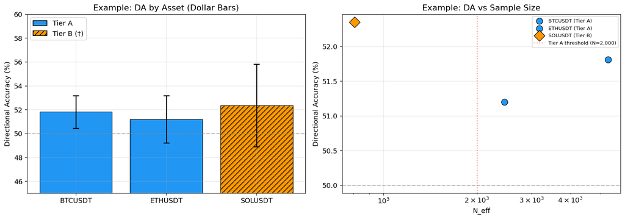

5.2 Chart Convention Summary

| Element | Tier A | Tier B |
| --- | --- | --- |
| Bar fill | Solid blue (#2196F3) | Solid orange (#FF9800) with hatching (///) |
| Scatter marker | Circle (o) | Diamond (D) |
| Error bars | Asymptotic CI | Bootstrapped CI (typically wider) |
| Legend entry | "Tier A" | "Tier B (†)" |
| Axis label | Standard | Append "†" to asset name |

```python
"""Cell 11 -- Section 5.2: Chart annotation template.

Demonstrate the Tier B bar-chart convention: hatched bars, different marker
styles, and legend entries explaining Tier B.
"""

# -- Example bar chart with Tier B flagging -----------------------------------
fig, axes = plt.subplots(1, 2, figsize=(14, 5))

# --- LEFT: Bar chart example -------------------------------------------------
ax1 = axes[0]
assets_ex: list[str] = ["BTCUSDT", "ETHUSDT", "SOLUSDT"]
da_values_ex: list[float] = [51.81, 51.20, 52.35]
tiers_ex: list[str] = ["A", "A", "B"]
n_eff_ex: list[int] = [5286, 2454, 808]

bar_colors: list[str] = []
bar_hatches: list[str] = []
for tier in tiers_ex:
    if tier == "A":
        bar_colors.append("#2196F3")
        bar_hatches.append("")
    else:
        bar_colors.append("#FF9800")
        bar_hatches.append("///")

bars_ex = ax1.bar(assets_ex, da_values_ex, color=bar_colors, edgecolor="black", linewidth=0.8)
for bar_obj, hatch in zip(bars_ex, bar_hatches, strict=True):
    bar_obj.set_hatch(hatch)

# Error bars (wider for Tier B to illustrate CI difference)
ci_widths: list[float] = [1.36, 1.98, 3.46]
ax1.errorbar(
    assets_ex,
    da_values_ex,
    yerr=ci_widths,
    fmt="none",
    ecolor="black",
    capsize=5,
    capthick=1.5,
    linewidth=1.5,
)

ax1.axhline(y=50, color="gray", linestyle="--", alpha=0.5, label="Random (50%)")
ax1.set_ylabel("Directional Accuracy (%)")
ax1.set_title("Example: DA by Asset (Dollar Bars)")
ax1.set_ylim(45, 60)

# Custom legend
tier_a_bar = mpatches.Patch(facecolor="#2196F3", edgecolor="black", label="Tier A")
tier_b_bar = mpatches.Patch(facecolor="#FF9800", edgecolor="black", hatch="///", label="Tier B (\u2020)")
ax1.legend(handles=[tier_a_bar, tier_b_bar], loc="upper left")

# --- RIGHT: Scatter chart example --------------------------------------------
ax2 = axes[1]

for i, (asset, da, tier, n_eff) in enumerate(zip(assets_ex, da_values_ex, tiers_ex, n_eff_ex, strict=True)):
    marker: str = "o" if tier == "A" else "D"  # Diamond for Tier B
    color: str = "#2196F3" if tier == "A" else "#FF9800"
    size: int = 100 if tier == "A" else 150
    ax2.scatter(
        n_eff,
        da,
        marker=marker,
        color=color,
        s=size,
        edgecolors="black",
        linewidth=0.8,
        zorder=5,
        label=f"{asset} (Tier {tier})",
    )

ax2.axhline(y=50, color="gray", linestyle="--", alpha=0.5)
ax2.axvline(
    x=TIER_A_THRESHOLD, color="red", linestyle=":", alpha=0.5, label=f"Tier A threshold (N={TIER_A_THRESHOLD:,})"
)
ax2.set_xlabel("N_eff")
ax2.set_ylabel("Directional Accuracy (%)")
ax2.set_title("Example: DA vs Sample Size")
ax2.legend(fontsize=8, loc="upper right")
ax2.set_xscale("log")

plt.tight_layout()
plt.show()

display(
    Markdown("""### 5.2 Chart Convention Summary

| Element | Tier A | Tier B |
|---------|--------|--------|
| Bar fill | Solid blue (#2196F3) | Solid orange (#FF9800) with hatching (///) |
| Scatter marker | Circle (o) | Diamond (D) |
| Error bars | Asymptotic CI | Bootstrapped CI (typically wider) |
| Legend entry | "Tier A" | "Tier B (\u2020)" |
| Axis label | Standard | Append "\u2020" to asset name |
""")
)
```

## Section 6: Downstream Phase References

Map where the Tier B protocol applies across all downstream phases. For each phase, specify exactly what changes compared to Tier A handling.

```python
"""Cell 12 -- Section 6: Downstream phase reference table.

Define exactly what Tier B changes in each downstream phase.
"""

phase_ref_data: list[dict[str, str]] = [
    {
        "Phase": "9 (Feature Pipeline)",
        "Tier A handling": "Standard feature matrix, standard config",
        "Tier B change": "Same features, but log N_eff and tier label added as metadata columns",
        "Rationale": "Tier label must propagate to all downstream consumers",
    },
    {
        "Phase": "10 (Classification)",
        "Tier A handling": "Ridge alpha from CPCV; LightGBM defaults from CPCV",
        "Tier B change": "Ridge alpha x 2; LightGBM min_child_samples x 2, "
        "num_leaves / 2, max_depth - 1; CPCV n_splits = 3 (not 5)",
        "Rationale": "Higher regularisation for smaller N; fewer CV folds to keep fold size adequate",
    },
    {
        "Phase": "11 (Regression)",
        "Tier A handling": "Standard regularisation; asymptotic CIs for DC-MAE, DC-RMSE",
        "Tier B change": "Same regularisation adjustments as Phase 10; "
        "bootstrapped 95% CIs (10,000 resamples) for all metrics",
        "Rationale": "Regression metrics more sensitive to outliers at small N; bootstrap is safer",
    },
    {
        "Phase": "12 (Recommendation)",
        "Tier A handling": "Recommendation output includes asset, bar_type, signal, confidence",
        "Tier B change": "Add 'tier' field to recommendation output; "
        "tier=B triggers position size reduction (e.g., Kelly fraction x 0.5)",
        "Rationale": "Less confidence in Tier B predictions warrants smaller positions",
    },
    {
        "Phase": "13 (Backtest)",
        "Tier A handling": "Full backtest with standard position sizing",
        "Tier B change": "Backtest results flagged with Tier B; performance metrics reported with bootstrapped CIs",
        "Rationale": "Backtest Sharpe/drawdown on 808 bars has very wide confidence intervals",
    },
    {
        "Phase": "14 (Evaluation)",
        "Tier A handling": "Primary evidence for thesis claims; standard statistical tests",
        "Tier B change": "NOT primary evidence; robustness check only; reported alongside Tier A with dagger notation",
        "Rationale": "MDE DA = 54.37% means only strong effects are detectable; insufficient power for primary claims",
    },
    {
        "Phase": "15 (Monte Carlo)",
        "Tier A handling": "Standard GBM validation with 10,000 paths",
        "Tier B change": "Same GBM validation, but interpret with caution: "
        "808-bar paths have high variance in Sharpe estimates",
        "Rationale": "Sharpe ratio from 808-bar backtest has ~2.5x wider CI than from 5,286 bars",
    },
    {
        "Phase": "RC4 (Go/No-Go)",
        "Tier A handling": "Asset counts toward 'majority of assets positive' criterion",
        "Tier B change": "SOLUSDT counts but with Tier B flag; if only SOLUSDT is positive, criterion does NOT pass",
        "Rationale": "Tier B result alone is insufficient evidence; must be corroborated by Tier A",
    },
]

phase_ref_df: pd.DataFrame = pd.DataFrame(phase_ref_data)
display(Markdown("### 6.1 Phase-by-Phase Tier B Protocol"))
display(
    phase_ref_df.style.set_caption("Downstream phase reference: Tier A vs Tier B handling").set_properties(
        **{"text-align": "left", "white-space": "pre-wrap"}
    )
)
```

6.1 Phase-by-Phase Tier B Protocol

Downstream phase reference: Tier A vs Tier B handling

[output not shown]

## Section 7: Formal Protocol Document

The complete, numbered Tier B handling protocol. This is the authoritative reference for all downstream phases.

### 7.1 Tier Classification Decision Rule

An (asset, bar_type) combination is classified based on its effective sample size N_eff (the number of clean rows after feature warmup and NaN removal):

| Tier | N_eff range | Treatment |
| --- | --- | --- |
| **A** | >= 2,000 | Standard pipeline: standard regularisation, asymptotic CIs, primary evidence |
| **B** | 500 -- 1,999 | Modified pipeline: stronger regularisation, bootstrapped CIs, robustness check only |
| **C** | < 500 | Excluded from modeling: statistical profiling only, no ML training |

**Current asset classification (dollar bars):**

| Asset | N_eff | Tier |
| --- | --- | --- |
| BTCUSDT | 5,286 | A |
| ETHUSDT | 2,454 | A |
| SOLUSDT | 808 | B |
| LTCUSDT | 199 | C (excluded) |

### 7.2 Complete Numbered Protocol

**P1. Labelling.** Every table, chart, and metric that includes SOLUSDT/dollar results MUST carry the Tier B label. Tables use dagger notation and orange highlighting. Charts use hatched bars and diamond markers.

**P2. Regularisation.** SOLUSDT/dollar models use strengthened regularisation:

- Ridge: alpha multiplied by 2.
- LightGBM: min_child_samples multiplied by 2, num_leaves divided by 2 (floor), max_depth reduced by 1 (minimum 2).
- CPCV: 3 folds (not 5) to maintain adequate fold size.

**P3. Confidence intervals.** All SOLUSDT/dollar metrics are reported with bootstrapped 95% CIs (10,000 resamples, percentile method). Tier A assets may use asymptotic (Wald) CIs.

**P4. Evidence hierarchy.** SOLUSDT/dollar results are NOT used as primary evidence for thesis claims. They serve as a robustness check:

- A claim supported by Tier A assets and corroborated by Tier B is strengthened.
- A claim supported by Tier A assets but contradicted by Tier B is flagged but not invalidated (Tier B may lack power to detect the effect).
- A claim supported ONLY by Tier B is NOT valid as primary evidence.

**P5. RC4 criterion.** For the "majority of assets positive" Go/No-Go criterion:

- SOLUSDT counts toward the majority tally with the Tier B flag.
- If SOLUSDT is the ONLY positive asset, the criterion does NOT pass.
- If at least one Tier A asset is positive AND SOLUSDT is also positive, SOLUSDT counts as corroborating evidence.

**P6. Position sizing.** The recommendation system applies a Kelly fraction discount for Tier B assets (e.g., multiply Kelly fraction by 0.5) to account for higher parameter uncertainty.

**P8. Future assets.** If new assets are added to the universe, they are classified using the same N_eff thresholds. The Tier B protocol applies automatically to any (asset, bar_type) combination with 500 <= N_eff < 2,000.

```python
"""Cell 13 -- Section 7.3: Summary comparison table (Tier A vs Tier B).

Final summary table showing all differences between tiers.
"""

summary_data: list[dict[str, str]] = [
    {
        "Aspect": "Classification threshold",
        "Tier A": "N_eff >= 2,000",
        "Tier B": "500 <= N_eff < 2,000",
    },
    {
        "Aspect": "MDE DA (alpha=0.05)",
        "Tier A": "<= ~52% (sensitive to small effects)",
        "Tier B": "~54% (only large effects detectable)",
    },
    {
        "Aspect": "Regularisation (Ridge)",
        "Tier A": "alpha from CPCV",
        "Tier B": "alpha x 2",
    },
    {
        "Aspect": "Regularisation (LightGBM)",
        "Tier A": "Standard hyperparams from CPCV",
        "Tier B": "min_child_samples x 2, num_leaves / 2, max_depth - 1",
    },
    {
        "Aspect": "CPCV folds",
        "Tier A": "5",
        "Tier B": "3",
    },
    {
        "Aspect": "Confidence intervals",
        "Tier A": "Asymptotic (Wald) acceptable",
        "Tier B": "Bootstrapped (10,000 resamples, percentile)",
    },
    {
        "Aspect": "Evidence role",
        "Tier A": "Primary evidence for thesis claims",
        "Tier B": "Robustness check only",
    },
    {
        "Aspect": "RC4 majority criterion",
        "Tier A": "Counts fully",
        "Tier B": "Counts with flag; cannot be sole positive asset",
    },
    {
        "Aspect": "Position sizing",
        "Tier A": "Full Kelly fraction",
        "Tier B": "Kelly fraction x 0.5",
    },
    {
        "Aspect": "Table styling",
        "Tier A": "Standard rows",
        "Tier B": "Orange background, dagger (\u2020) suffix",
    },
    {
        "Aspect": "Chart styling",
        "Tier A": "Blue solid bars, circle markers",
        "Tier B": "Orange hatched bars, diamond markers",
    },
    {
        "Aspect": "Reporting language",
        "Tier A": "Standard",
        "Tier B": "Explicit caveat about limited power and MDE",
    },
]

summary_df: pd.DataFrame = pd.DataFrame(summary_data)
display(Markdown("### 7.3 Tier A vs Tier B: Complete Comparison"))
display(
    summary_df.style.set_caption("Complete protocol comparison between Tier A and Tier B handling").set_properties(
        **{"text-align": "left"}
    )
)
```

7.3 Tier A vs Tier B: Complete Comparison

Complete protocol comparison between Tier A and Tier B handling

[output not shown]

```python
"""Cell 14 -- Section 7.4: Final status and impact statement.

Conclude the notebook with the formal impact on RC2 conclusions.
"""

display(
    Markdown("""### 7.4 Impact on RC2 Conclusions

**RC2 Section 8 stated:** "SOLUSDT: MARGINAL (N_eff = 808 < 1,000) -- included but flagged."

**This appendix resolves the gap** by defining exactly what "flagged" means in practice:

1. **Tier B classification is now formally defined** with concrete N_eff thresholds
   (Rule B1: 500 <= N_eff < 2,000).

2. **Regularisation adjustments are prescribed** (2x multiplier for Ridge alpha and
   LightGBM min_child_samples) with theoretical justification from the bias-variance
   tradeoff and optimal Ridge penalty scaling.

3. **Bootstrap CI requirement is empirically validated** through coverage simulations
   showing that bootstrap provides robust coverage at N=808.

4. **Visual flagging conventions are established** (orange/hatched for tables/charts)
   with reusable template functions.

5. **Evidence hierarchy is explicit:** Tier B results serve as robustness checks,
   not primary evidence.

6. **Every downstream phase has a concrete Tier B protocol** defined in Section 6.

**Post-hoc deviations introduced:** 0.
**Trial count:** remains at 60.
**RC2 GO decision:** unchanged (strengthened by having explicit small-sample handling).
""")
)

print("Notebook complete. All sections executed successfully.")
```

7.4 Impact on RC2 Conclusions

**RC2 Section 8 stated:** "SOLUSDT: MARGINAL (N_eff = 808 < 1,000) -- included but flagged."

**This appendix resolves the gap** by defining exactly what "flagged" means in practice:

1. **Tier B classification is now formally defined** with concrete N_eff thresholds (Rule B1: 500 <= N_eff < 2,000).

2. **Regularisation adjustments are prescribed** (2x multiplier for Ridge alpha and LightGBM min_child_samples) with theoretical justification from the bias-variance tradeoff and optimal Ridge penalty scaling.

3. **Bootstrap CI requirement is empirically validated** through coverage simulations showing that bootstrap provides robust coverage at N=808.

4. **Visual flagging conventions are established** (orange/hatched for tables/charts) with reusable template functions.

5. **Evidence hierarchy is explicit:** Tier B results serve as robustness checks, not primary evidence.

6. **Every downstream phase has a concrete Tier B protocol** defined in Section 6.

**Post-hoc deviations introduced:** 0. **Trial count:** remains at 60. **RC2 GO decision:** unchanged (strengthened by having explicit small-sample handling).

```
Notebook complete. All sections executed successfully.
```